# Analiza danych z serii książek The Game of Thrones na temat śmierci bohaterów

Sofiya Rylova

2022-01-31

# Kilka słów o projekcie

Celem mojego projektu jest przedstawienie analizy danych z serii książek Game of Thrones, dane wyniki pomogą lepiej zrozumieć fabułę i dowiedzieć się o ukrytych ciekawostkach. Dane zostałe pobrane ze strony do [uczenia maszynowego](https://www.kaggle.com).

## Pierwszy wykres pokazuje ile bohaterów zginęło w każdej książce:

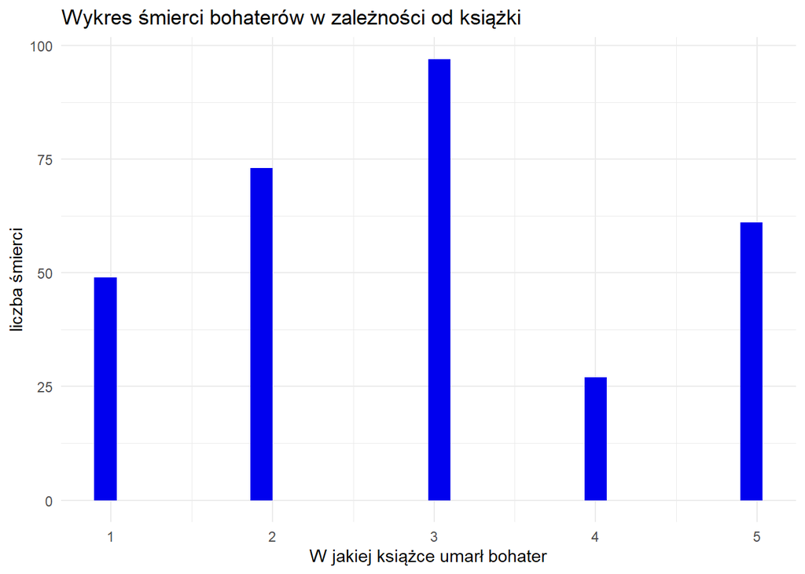

## Analiza:

Z naszego wykresu widzimy, że największa liczba śmierci jest w 3 książce, natomiast w 4 książce najmniej śmierci. Takie liczby wynikają z tego, że kulminacja wojny, która opisana jest w 3 książce jest bezpośrednio związana z liczbą śmierci, również 3 książka jest dłuższa, niż pierwsza i druga.

## Potwierdzenie faktu, że większej liczbie śmierci towarzyszy większa liczba bitew znajduję się na następującym wykresie:

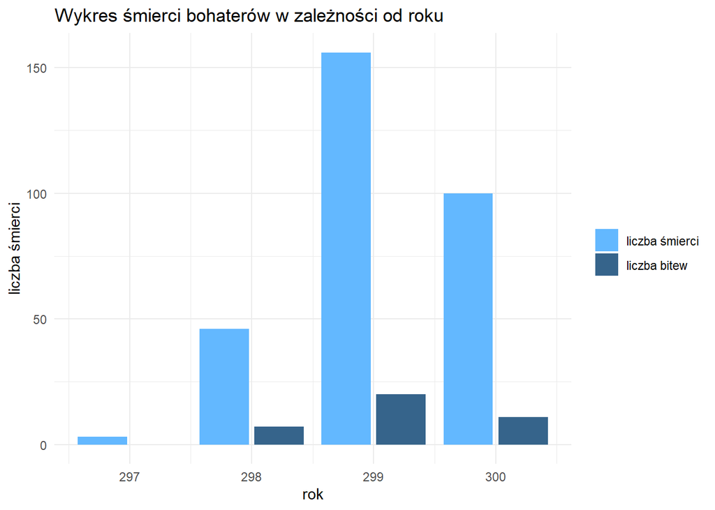

## Analiza:

Powyższy wykres sugeruje, że duże wahania liczby śmierci w poszczególnych latach są ściśle powiązane z liczbą wojen jakie się wtedy odbywały. Ponadto, w czasie pokoju umiera o wiele mniej bohaterów, niż w czasie wojny, co potwierdzają dane z roku 297.

## Uwzględnienie płci zmarłych bohaterów:

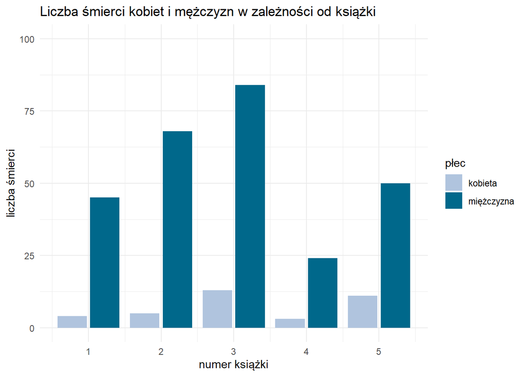

## Analiza:

Zaleźnośći zaobserwowane na pierwszym wykresie, to znaczy rosnąca liczba śmierci w pierwszych trzech książkach oraz zdecydowanie najmniejsza liczba śmierci w czwartej książce utrzymują się przy uwzględnieniu płci zmarłej osoby.

## Porównanie aktywności agresorów:

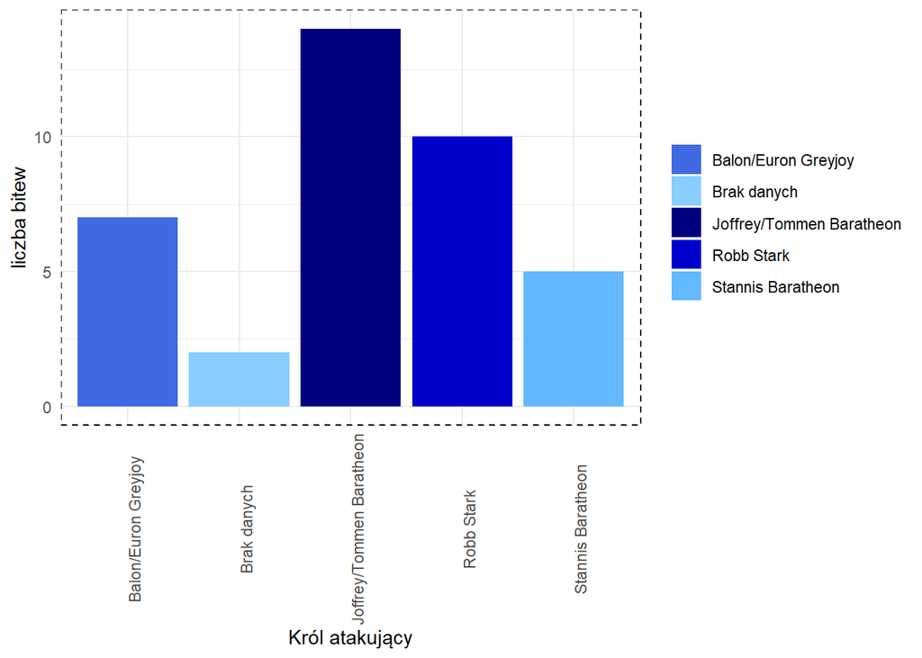

## Analiza:

Wykres zaprezentowany powyżej pokazuje, że najczęściej atakującymi królami są Robb Stark oraz Joffrey i Tommen Baratheon. Każdy z nich atakował innego króla co najmniej 10 razy.

## Królowie walczący w poszczególnych bitwach

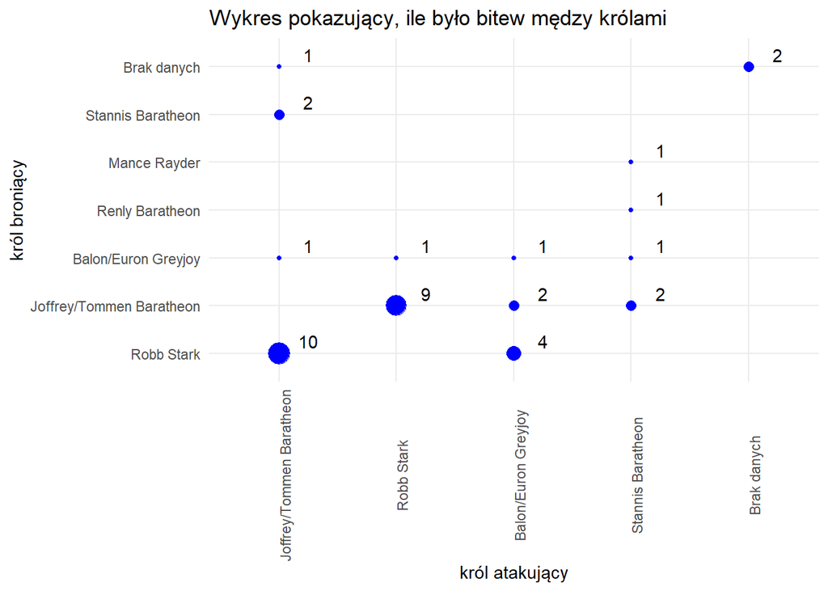

## Struktura wieku i status społeczny w chwili śmierci:

| wiek | liczba_smierci | liczba_arystokratow |
| --- | --- | --- |
| (0,18] | 110 | 25 |
| (18,29] | 117 | 45 |
| (29,45] | 76 | 51 |
| (45,60] | 53 | 34 |
| (60,85] | 39 | 31 |
| (85,100] | 34 | 25 |

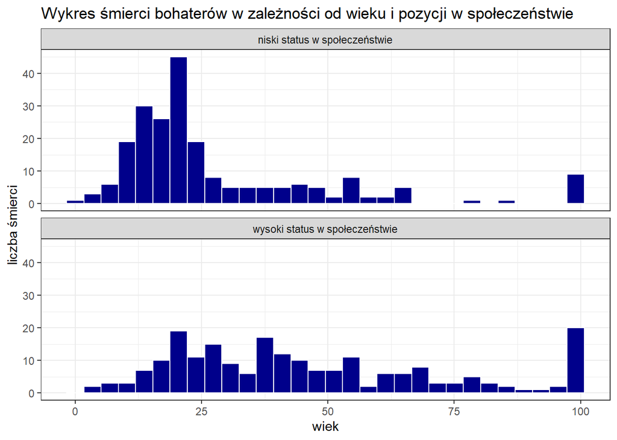

## Analiza:

Najwięcej śmierci dotyczy osób w młodym wieku. Im starszy wiek tym mniej osób go dożywa, więc obserwowane liczby śmierci są coraz mniejsze. Nie dotyczy to jednak arystokracji , w której najwięcej śmierci przypada na średni wiek. Można to tłumaczyć tym, że prawdopodobieństwo śmierci w wieku dziecięcym, nastoletnim i młodzieńczym wśród arystokracji, jest dużo niższe, niż w całym społeczeństwie glównych bohaterów książek.

# Wyniki:

Mam nadzieje, że przedstawiłam kilka ciekawych rzeczy na temat książKi, i w dobry sposób pokazałam je za pomocą wykresów. Dziękuję, Sofiya Rylova

# Źródła informacji:

[link do danych](https://www.kaggle.com/mylesoneill/game-of-thrones)